# ¿Por qué Pooling?

David Jiménez González

5/13/2020

## Introducción

Esta idea nació como una inquietud a partir un articulo sobre el trabajo de Dina Berenbaum (disponible en el medio [Times of Israel](https://www.timesofisrael.com/to-ease-global-virus-test-bottleneck-israeli-scientists-suggest-pooling-samples/) ), donde se indica la posibilidad de emplear pruebas no sólo a individuos con potencial de estar infectados, sino a grupos de ellos. Lo más intrigante de este efoque radica en lo sencillo del concepto. Con esto en mente se trata de evaluar las propiedades numéricas de este tipo de tests en una población infectada con COVID19 y realizar una evaluación preliminar de las potenciales ventajas que este procedimiento podría presentar.

Para ello, se construyó una simulación muy sencilla donde se trata de emular las características de una población con diferentes niveles de contagio. Se aprovecha esta simulación para probar diferentes formas de organizar las pruebas y el tamaño de estas para así de alguna forma “optimizar” el uso de estas, que equivale conceptualmente a un aumento en la capacidad de evaluación.

## Construcción de la población contagiada

Es importante notar que esta población tiene las características de una fase inicial de la epidemia donde los casos se distribuyen al azar. Queremos que, al igual que en una población normal los casos de alguna forma se agrupen cerca de los grupos sociales donde interactúan. Para ello construimos una función de probabilidad de contagio.

Esta función emplea el número de casos contagiados en los grupos a los que pertenece cada individuo y además agrega un componente de aleatoriedad. Por facilidad e interpretabilidad se emplea una función logística para calcular dicha probabilidad.

$$p_{ij} = \frac{1}{1+e^{-l_{ij}}}$$
$$l_{ij} = \alpha_{fam}*n_{fam_{ij}} + \alpha_{edi}*n_{edi_{ij}}+\alpha_{vec_{ij}}*n_{vec} + \alpha_{p_{0}}*p_{0_i}$$
Donde se emplea para el paso de tiempo que se está analizando $t_i$ el porcentaje de personas infectadas $n_x$ de cada uno de los grupos a los que pertenece el individuo $j$, el porcentaje total de contagiados $p_{0_i}$ y ciertos pesos $\alpha_x$ para así determinar la probabilidad de que el individuo $j$ esté contagiado en el siguiente paso de tiempo $t_{i+1}$.

```r
set.seed(5)

#Se crea la función de probabilidad en el ambiente
InfProb<-createInfPFun()

#Se crea la población inicial y se calcula para cada individuo pj
sus<-createSus(N = 1000, pI = 0.005)

#La tabla de la primera iteración podría verse así
knitr::kable(head(sus, 5))
```

| sus | fam | inf | buil | nei | lng | lat | infFam | infBuil | infNei | infP |
| --- | --- | --- | --- | --- | --- | --- | --- | --- | --- | --- |
| 1 | 163 | FALSE | 44 | 9 | 16 | 4 | 0 | 0 | 0 | 0.5004332 |
| 2 | 161 | FALSE | 30 | 9 | 16 | 4 | 0 | 0 | 0 | 0.5004332 |
| 3 | 123 | FALSE | 99 | 11 | 20 | 18 | 0 | 0 | 0 | 0.5004332 |
| 4 | 16 | FALSE | 34 | 2 | 7 | 15 | 0 | 1 | 1 | 0.5783582 |
| 5 | 128 | FALSE | 31 | 17 | 13 | 7 | 0 | 0 | 0 | 0.5004332 |

Para visualizar de alguna forma los vecindarios le asignamos de forma aleatoria a los vecindarios una longitud y latitud.

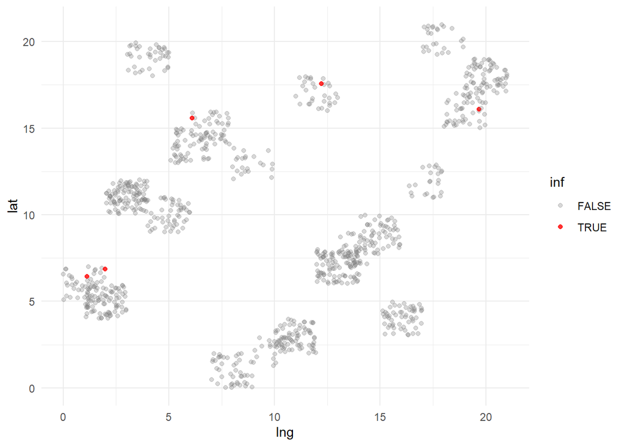

Para obtener los casos contagiados en el tiempo $t_{i+1}$ se toma el valor de probabilidad para cada individuo y se determina si el mismo está por encima de un umbral definido como $u_{ij} = u_0 + \mathcal{N}(\mu,\sigma )$ donde $u_0$ es un valor base y a este se le agrega el valor de una distribución normal. Si en efecto se encuentra por encima del umbral o bien ya estaba contagiado la condición del individuo hasta la última iteración será como contagiado. Nótese que en este modelo no se tienen casos recuperados ya que la finalidad es luego, para poblaciones con diferentes niveles de contagio, evaluar el uso de la metodología anteriormente mencionada.

Luego de unas cuantas iteraciones la población aumenta su número de casos infectados.

```r
p0<- sum(sus$inf) / nrow(sus)
print(p0)
```

```
## [1] 0.005
```

```r
for(i in 1:4){
   sus<- nextIter(sus, threshold = 0.8, p0 = p0)
   p0<- sum(sus$inf) / nrow(sus)
   print(paste0("p0 = ",p0))
}
```

```
## [1] "p0 = 0.011"
## [1] "p0 = 0.035"
## [1] "p0 = 0.079"
## [1] "p0 = 0.129"
```

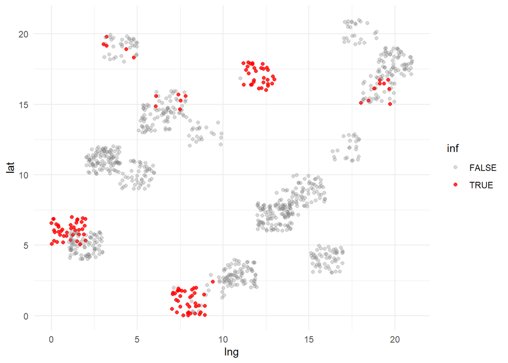

## Procedimiento de pruebas en grupo (pooling)

El procedimiento de pooling según se entiende implica mezclar las muestras de $m$ cantidad de individuos en un grupo y detectar ausencia y presencia del virus. Este procedimiento es particularmente efectivo cuando se pueden descartar grandes cantidades de individuos, es decir, cuando la probabilidad de haya un individuo infectado en cada grupo es baja. De hecho, si esta probabilidad es alta, es probable que la cantidad de muestras necesarias sea mayor a la que se requeriría en el caso de hacer pruebas individuales.

Se aprovechará entonces la definición de población contagiada previamente construida para determinar si uso de *pooling* para reducir el número total de pruebas necesarias para identificar los casos positivos $T$ . Si suponemos que solamente se efectuará una ronda de agrupaciones (procedimiento no recursivo) y además que los tamaños de los grupos $m$ son iguales, entonces el total de muestras necesarias se puede definir como $T = N - d +g$, donde: $d:=$ número de invividuos descartados mediante las pruebas grupales, $g:=$ número de grupos.

Queremos en dicho contexto evaluar cuál es el mínimo número esperado de $T$ para diferentes proporciones de infección de la población $p_0$, diferentes tamaños de grupo $m$ y diferentes formas de ordenar los grupos. Este último punto es interesante pues, intuitivamente, se entiende que poner en grupos aparte a las personas con alta probabilidad de estar infectados y a personas con baja probabilidad de estar infectados probablemente ayude a aumentar la cantidad de personas descartadas $d$ por las pruebas grupales, la cual es la variable más importante para poder reducir el número total de pruebas.

Primero nos concentraremos en evaluar el efecto del tamaño del grupo en una población con una proporción constante de infectados $p_0$. Para ello probaremos desde grupos de 2 hasta 64 personas (referenciando el artículo anteriormente mencionado). Para evaluar la intuición de que colocar individuos con un nivel similar de probabilidad de estar infectados o bien con cierta cercanía aumenta la efectividad del procedimiento de *pooling* se ordenan los valores por familia, por edificio, vecindad y también por probabilidad de estar infectados.

Nótese que al ordenar por alguna de dichas clasificaciones, pero para diferentes tamaños de grupo, existe la probabilidad en algunos casos de que en una prueba se estén testeando más de una famila, edificio, etc.; sin embargo, se está concentrando los casos positivos entre sí y también los casos negativos entre sí mejorando así la probabilidad de que existan grupos sin ningún caso.

Otro punto importante de tratar es que estamos usando la variable $p_{ij}$ que es la variable con la que de hecho se construyó la simulación. Esto en cierta medida es como emplear un oráculo que me indica la mejor aproximación a la probabilidad real de que un individuo esté infectado, por lo que los resultados deben ser interpretados con precaución. Cabe resaltar que en este caso al ser una variable continua realmente estamos *ordenando* según $p_{ij}$ para luego *agrupar* esa poblacion ordenada.

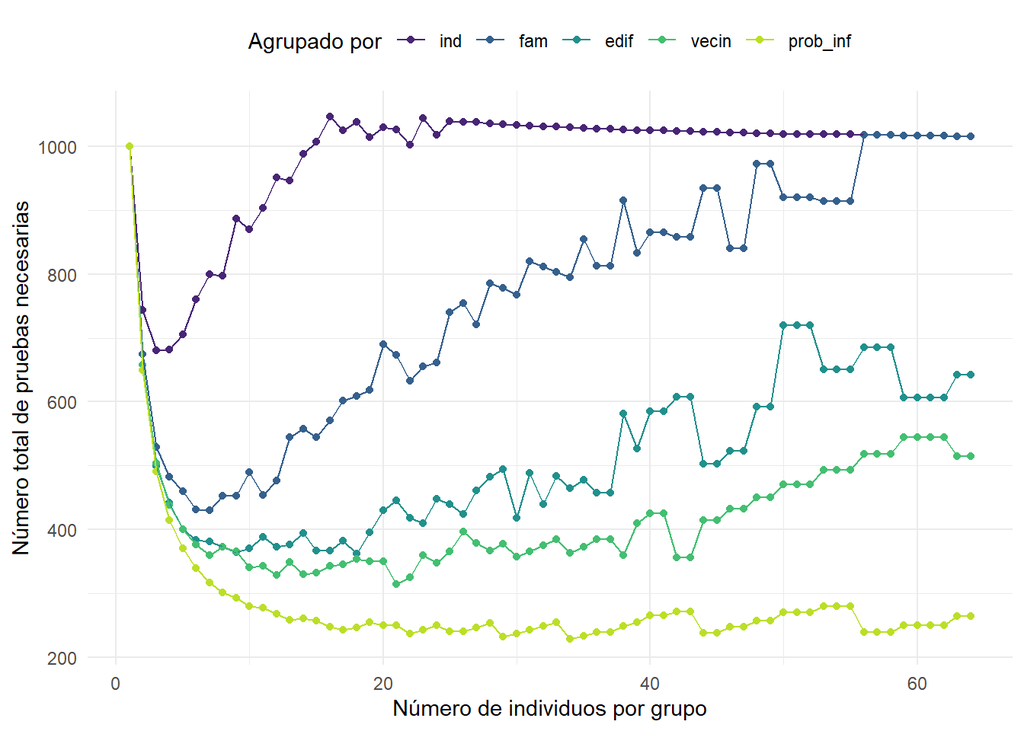

En la figura anterior se muestra cómo, para la gran mayoría de casos, existe una disminución significativa del número de pruebas necesarias respecto a la condición de analizar a todos los individuos. Puede observarse que el caso base de *pooling* donde no ser ordena tiene los peores resultados mientas que el mejor resultado se obtiene empleando $p_{ij}$ para ordenar.

Es interesante que para cada una de las agrupaciones el óptimo se alcanza en tamaños de grupo distintos, mientras más granular sea la agrupación más pequeño el tamaño de grupo en el que se alcanza una disminución mayor en el número de pruebas necesarias.

En cierta medida los resultados anteriores confirman las intuiciones indicadas con anterioridad respecto al valor de ordenar o agrupar antes de realizar el procedimiento de *pooling*. Hay que comprobar que estos hallazgos se mantienen para distintos porcentajes de infección en la población.

Para ello simulamos $100$ poblaciones con $p_{0_i}$, $N$ y $u_0$ diferentes. De donde se obtiene para cada uno de los tipos de agrupación y para cada momento $t_i$ el valor mínimo de pruebas necesario.

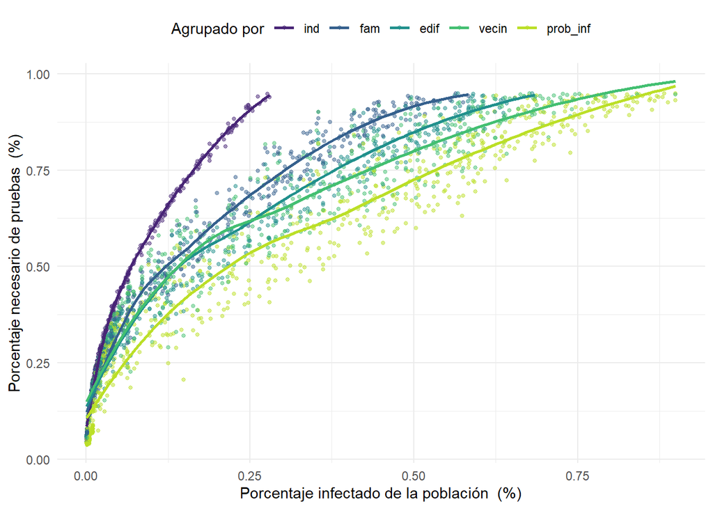

Si bien existe dispersión en los resultados, la relación que se había descrito previamente sobre la eficiencia de diferentes estrategias de orden o agrupamiento previos al *pooling* se mantienen. Se muestra cómo al aumentar el porcentaje de contagios de la población la eficiencia del procedimiento disminuye, pero dicha disminución es mucho más marcada mientras menos precisa sea la agrupación en términos de acercar personas contagiadas y acercar personas no contagiadas. En este sentido podemos pensar que el caso sin agrupar es un límite superior y el caso ordenado por probabilidad es un límite inferior de las posibilidades que podría tener el procedimiento de ordenamiento previo al *pooling*.

Es importante notar que tanto para el caso donde se conoce un $p_0$ o bien si se conoce la distribución de $p_{ij}$ es posible determinar numéricamente el valor de $m$ óptimo para realizar las pruebas. Además, en el caso sin agrupar se puede conocer directamente el valor de $m$ analíticamente.

### El caso de Costa Rica

En el país se han venido realizando estrategias de rastreo para identificar a personas con el virus en donde se buscan personas con cierta probabilidad de haber contraído el virus y se les aplica la prueba. Tomando los datos de las publicaciones de la cuenta de twitter del Ministerio de Salud ( @[msaludcr](https://twitter.com/msaludcr/) ) de descartados y confirmados en varios días se observa que en general los valores acumulados de pruebas respecto a los valores acumulados de personas se encuentran entre $p_0 = 0.16$ y $p_0 = 0.07%$. Esto implica que podría, según los datos, reducirse el número de pruebas necesarias en un orden de magnitud de $40\%$ o más en dependencia de qué tan efectiva sea la identificación de $p_{ij}$ para cada individuo.

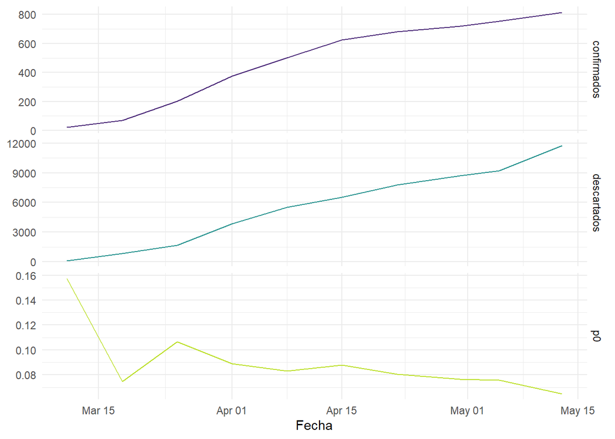

Este resultado preliminar al menos indica que valdría la pena evaluar la posibilidad de realizar el procedimiento para estas pruebas, en especial debido a que la tendencia de $p_0$ en las muestras de la CCSS es a la baja. Además, pareciera que en el caso de una reapertura tener capacidad de descartar rápidamente grandes grupos de personas es útil para el control epidemiológico. Adicionalmente, recientemente se indicó que el AyA se encuentra realizando pruebas de presencia/ausencia de COVID19 en las aguas residuales. Esto indicaría que es factible identificar que el virus se encuentra o no en una muestra en bajas concentraciones.

Respecto a la factibilidad de obtener un valor de $p_{ij}$ se entiende que se podría generar dicha estimación con base en la base de datos generada en la CCSS de los casos positivos y la información que se le recabe a cada una de las personas que se realicen la prueba tales como síntomas, lugar de habitación etc. probablemente disponible ya en la aplicación *EDUS*. Esto mediante algún método de aprendizaje estadístico (o aprendizaje de máquina).

## Extras

### Solución analítica del óptimo $m$ para el caso de *pooling* sin ordenamiento

Nótese que para $N$ suficientemente grande $g \approx N/m$; además, suponiendo dado que $p_0$ se distribuye uniformemente en todos los grupos sabemos que la esperanza de individuos descartados puede ser definida como: $\mathbb{E} (d) = g\, m\,(1-p_0)^m \approx N(1-p_0)^m$

Para obtener el mínimo número esperado de $T$, dado un $p_0$ entonces minimizamos respecto a $m$.

$$\underset{m}{\operatorname{argmin}}(\mathbb{E}(T)) =
\underset{m}{\operatorname{argmin}}((N - N(1-p_0)^m + N/m))=
\sqrt{\frac{-1}{\log(1-p_0)(1-p_0)^m}}$$

### Preguntas interesantes por responder

Además del desarrollo anteriormente expuesto, hay muchas preguntas que pareciera interesante tratar de responder y que podrían indicar un norte en caso de que se quisiera evaluar la posibilidad de emplear *pooling*. Algunas de ellas se describen a continuación.

- ¿Operativamente es factible realizar el procedimiento?
- ¿Qué tan factible es generar una función de probabilidad de infección con base en los datos disponibles en la CCSS?
- ¿Qué pasa si usamos *pooling* no sólo en una primera instancia, sino de forma recursiva?
- ¿Qué pasa si usamos tamaños de grupo variable en el procedimiento: más pequeños para los casos donde la probabilidad de contagio es mayor y más grandes donde la probabilidad de contagio es menor?

### Colaboradores

La elaboración de estas ideas no fue un trabajo individual, las siguientes personas colaboraron tanto la conceptualización general como en recomendaciones específicas sobre temas técnicos asociados al desarrollo del modelo y del documento.

En orden alfabético de apellido: Juan José Leitón Montero, Rubén Rodríquez Román, Enrique Saures Apuy, Josué Vargas Amador,